# Salary Project

pg606@scarletmail.rutgers.edu

2024-04-29

```r
library(ggplot2)
library(corrplot)
library(factoextra)
library(psych)
library(NbClust)
library(magrittr)
library(tidyr)
library(reshape2)
library(MASS)
library(memisc)
library(ROCR)
library(dplyr)
library(klaR)
library(caTools)
library(pROC)
library(caret)
sc_dataset <- read.csv("/Users/Prateekg/Documents/MVA/Salary_multiple_regression.csv", row.names=1)
str(sc_dataset)
```

```
## 'data.frame':    10 obs. of  15 variables:
##  $ job_category         : chr  "Machine Learning and AI" "Machine Learning and AI" "Machine Learning and AI" "Machine Learning and AI" ...
##  $ salary_currency      : chr  "USD" "EUR" "USD" "USD" ...
##  $ employee_residence   : chr  "United States" "France" "Czech Republic" "Ghana" ...
##  $ experience_level     : chr  "Senior" "Senior" "Mid-level" "Mid-level" ...
##  $ employment_type      : chr  "Full-time" "Full-time" "Contract" "Full-time" ...
##  $ work_setting         : chr  "Remote" "Hybrid" "Remote" "In-person" ...
##  $ company_location     : chr  "United States" "France" "Canada" "Ghana" ...
##  $ company_size         : chr  "M" "M" "L" "S" ...
##  $ Salary_Level         : chr  "High" "High" "Low" "Low" ...
##  $ work_year            : int  2020 2016 2018 2017 2023 2021 2022 2015 2013 2014
##  $ salary               : int  305100 150000 50000 30000 140000 423000 222200 258000 100000 160000
##  $ Years.of.experience  : num  10 5 4 3 5 2.5 3.5 2.5 7 5.5
##  $ No.of.companies      : int  4 2 1 1 3 1 3 2 5 4
##  $ salary_in_usd        : int  305100 161952 50000 30000 140000 423000 222200 258000 100000 160000
##  $ salaryLevel.High.Low.: int  1 1 0 0 0 1 1 1 0 1
```

```r
correlation_matrix <- cor(sc_dataset[,10:15])
correlation_matrix
```

```
##                         work_year       salary Years.of.experience
## work_year              1.00000000  0.372568821         -0.08522355
## salary                 0.37256882  1.000000000          0.01083848
## Years.of.experience   -0.08522355  0.010838475          1.00000000
## No.of.companies       -0.25467247 -0.008743012          0.74237943
## salary_in_usd          0.36751354  0.999511836          0.01181610
## salaryLevel.High.Low.  0.03711348  0.740367687          0.01851852
##                       No.of.companies salary_in_usd salaryLevel.High.Low.
## work_year                -0.254672470    0.36751354            0.03711348
## salary                   -0.008743012    0.99951184            0.74036769
## Years.of.experience       0.742379427    0.01181610            0.01851852
## No.of.companies           1.000000000   -0.01339473            0.06019293
## salary_in_usd            -0.013394725    1.00000000            0.75083999
## salaryLevel.High.Low.     0.060192927    0.75083999            1.00000000
```

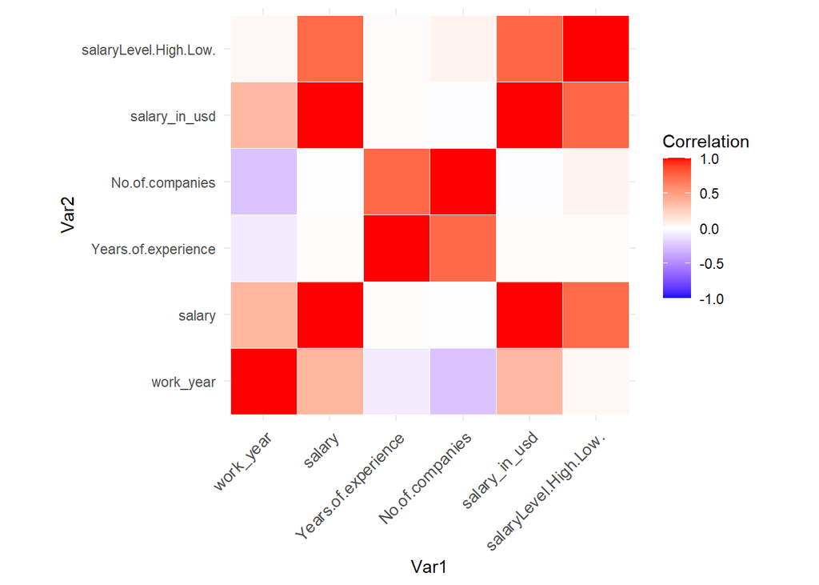

```r
ggplot(melt(correlation_matrix), aes(Var1, Var2, fill = value)) +
  geom_tile(color = "white") +
  scale_fill_gradient2(low = "blue", high = "red", mid = "white",
                       midpoint = 0, limit = c(-1,1), space = "Lab",
                       name="Correlation") +
  theme_minimal() +
  theme(axis.text.x = element_text(angle = 45, vjust = 1, size = 10, hjust = 1)) +
  coord_fixed()
```

```r
#PCA

sc_dataset_pca <- prcomp(sc_dataset[,10:15],scale=TRUE)
sc_dataset_pca
```

```
## Standard deviations (1, .., p=6):
## [1] 1.67013194 1.34613539 0.96025657 0.49615197 0.47959367 0.01758624
##
## Rotation (n x k) = (6 x 6):
##                               PC1         PC2         PC3        PC4        PC5
## work_year             -0.25829302  0.25123513  0.84902459 -0.1763753 -0.3438189
## salary                -0.58613197 -0.03348655 -0.00160896  0.3261011  0.2409713
## Years.of.experience    0.01346801 -0.66369483  0.31691578 -0.4413295  0.5138485
## No.of.companies        0.03302182 -0.69324025  0.07478279  0.4341134 -0.5693388
## salary_in_usd         -0.58756606 -0.03343908 -0.01103376  0.2930167  0.2431065
## salaryLevel.High.Low. -0.49318184 -0.11648396 -0.41593850 -0.6272678 -0.4200401
##                                PC6
## work_year              0.001781287
## salary                -0.700654155
## Years.of.experience   -0.008955060
## No.of.companies        0.011573900
## salary_in_usd          0.713138607
## salaryLevel.High.Low. -0.017313588
```

```r
summary(sc_dataset_pca)
```

```
## Importance of components:
##                           PC1    PC2    PC3     PC4     PC5     PC6
## Standard deviation     1.6701 1.3461 0.9603 0.49615 0.47959 0.01759
## Proportion of Variance 0.4649 0.3020 0.1537 0.04103 0.03834 0.00005
## Cumulative Proportion  0.4649 0.7669 0.9206 0.96161 0.99995 1.00000
```

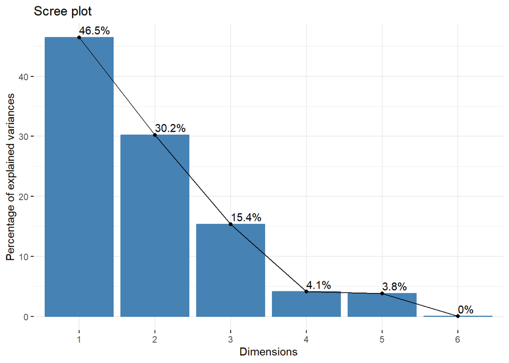

```r
fviz_eig(sc_dataset_pca, addlabels = TRUE)
```

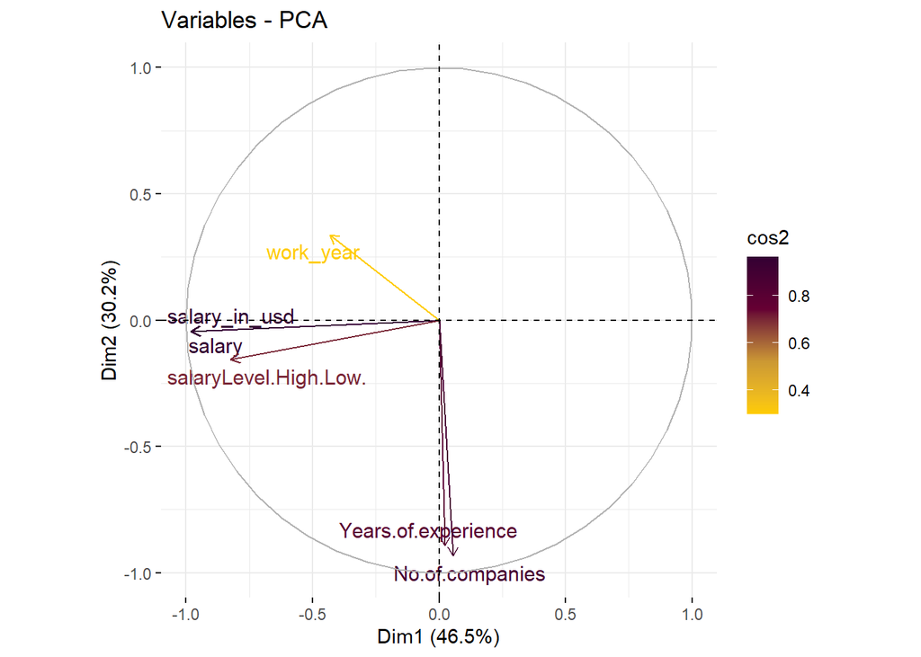

```r
fviz_pca_var(sc_dataset_pca,col.var = "cos2",
             gradient.cols = c("#FFCC00", "#CC9933", "#660033", "#330033"),
             repel = TRUE)
```

```r
#EFA

fit.pc <- principal(sc_dataset[,10:15], nfactors=3, rotate="varimax")
fit.pc
```

```
## Principal Components Analysis
## Call: principal(r = sc_dataset[, 10:15], nfactors = 3, rotate = "varimax")
## Standardized loadings (pattern matrix) based upon correlation matrix
##                         RC1   RC2   RC3   h2    u2 com
## work_year              0.15 -0.11  0.96 0.97 0.035 1.1
## salary                 0.94  0.01  0.27 0.96 0.040 1.2
## Years.of.experience   -0.01  0.94  0.04 0.89 0.109 1.0
## No.of.companies        0.03  0.92 -0.19 0.88 0.121 1.1
## salary_in_usd          0.95  0.01  0.26 0.97 0.035 1.2
## salaryLevel.High.Low.  0.91  0.01 -0.17 0.86 0.137 1.1
##
##                        RC1  RC2  RC3
## SS loadings           2.64 1.74 1.14
## Proportion Var        0.44 0.29 0.19
## Cumulative Var        0.44 0.73 0.92
## Proportion Explained  0.48 0.32 0.21
## Cumulative Proportion 0.48 0.79 1.00
##
## Mean item complexity =  1.1
## Test of the hypothesis that 3 components are sufficient.
##
## The root mean square of the residuals (RMSR) is  0.05
##  with the empirical chi square  0.64  with prob <  NA
##
## Fit based upon off diagonal values = 0.99
```

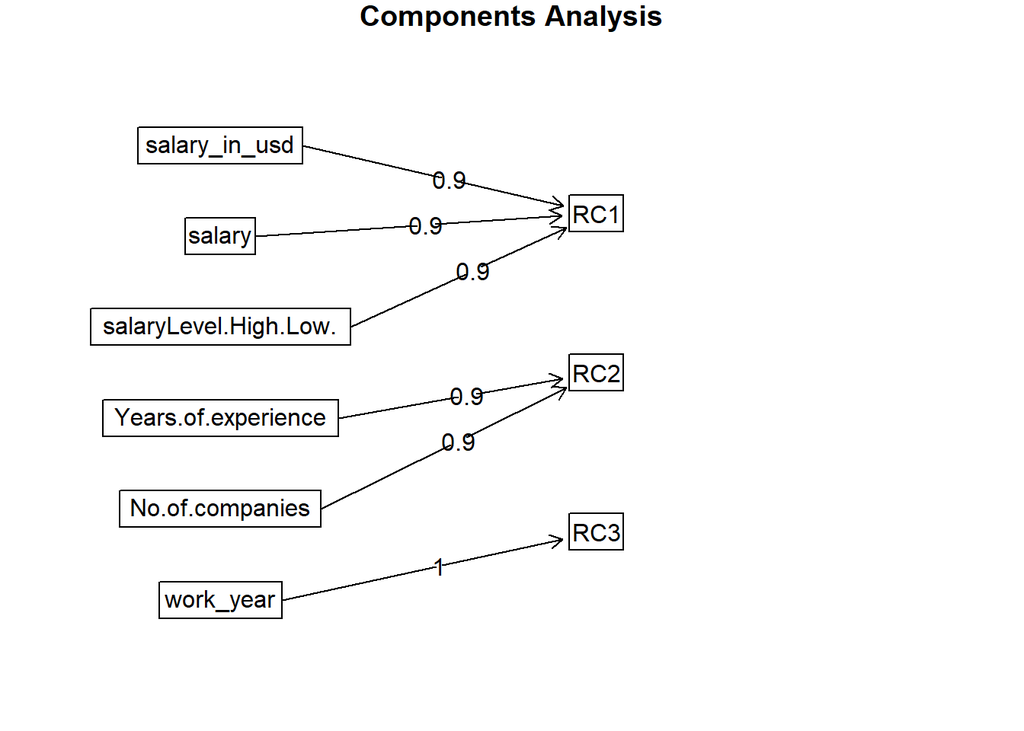

```r
fa.diagram(fit.pc)
```

```r
vss(sc_dataset[,10:15])
```

[output not shown]

[output cut: 16 more lines]

[output not shown]

[output not shown]

[output not shown]

[output cut: 12 more lines]

[output not shown]

[output not shown]

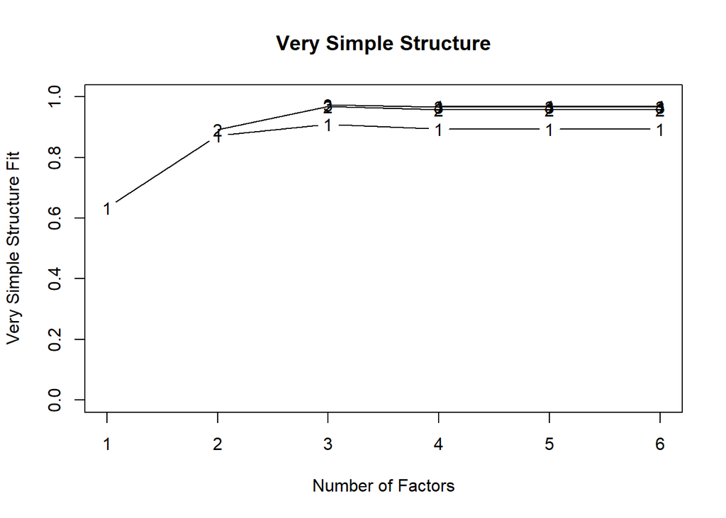

```
##
## Very Simple Structure
## Call: vss(x = sc_dataset[, 10:15])
## VSS complexity 1 achieves a maximimum of 0.91  with  3  factors
## VSS complexity 2 achieves a maximimum of 0.97  with  3  factors
##
## The Velicer MAP achieves a minimum of 0.2  with  1  factors
## BIC achieves a minimum of  22128274  with  2  factors
## Sample Size adjusted BIC achieves a minimum of  22128286  with  2  factors
##
## Statistics by number of factors
##   vss1 vss2  map dof   chisq prob sqresid  fit RMSEA     BIC   SABIC complex
## 1 0.63 0.00 0.20   9 2.6e+07    0    4.40 0.63   533 2.6e+07 2.6e+07     1.0
## 2 0.87 0.89 0.22   4 2.2e+07    0    1.29 0.89   744 2.2e+07 2.2e+07     1.1
## 3 0.91 0.97 0.45   0 5.6e+00   NA    0.32 0.97    NA      NA      NA     1.1
## 4 0.89 0.96 0.99  -3 4.6e+00   NA    0.39 0.97    NA      NA      NA     1.2
## 5 0.89 0.96 1.00  -5 3.7e+00   NA    0.39 0.97    NA      NA      NA     1.2
## 6 0.89 0.96   NA  -6 2.8e+00   NA    0.39 0.97    NA      NA      NA     1.2
##    eChisq    SRMR eCRMS eBIC
## 1 1.3e+01 0.21112  0.27 -7.4
## 2 8.9e-01 0.05432  0.11 -8.3
## 3 6.8e-04 0.00151    NA   NA
## 4 1.3e-04 0.00067    NA   NA
## 5 1.3e-04 0.00067    NA   NA
## 6 1.3e-04 0.00067    NA   NA
```

```r
#Clustering

efa_data <- as.data.frame(fit.pc$scores)
efa_data
```

```
##                                           RC1        RC2        RC3
## AI Architect                        0.8494983  1.7962069  0.7910111
## AI Developer                        0.2074946 -0.2445263 -0.7550633
## AI Engineer                        -1.2415290 -0.7418143  0.2312451
## AI Scientist                       -1.3034728 -1.0072021 -0.1343031
## Analytics Engineer                 -0.8908503  0.3321696  1.6504483
## Applied Machine Learning Scientist  1.5895733 -1.0727558  0.8077130
## Applied Scientist                   0.4267395 -0.1265104  0.7501591
## AWS Data Architect                  0.8627679 -0.8518371 -1.0507336
## Azure Data Engineer                -0.8081966  1.3520165 -0.9630738
## BI Analyst                          0.3079750  0.5642530 -1.3274029
```

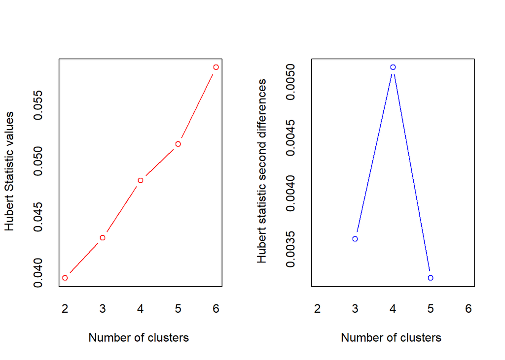

```
## *** : The Hubert index is a graphical method of determining the number of clusters.
##                 In the plot of Hubert index, we seek a significant knee that corresponds to a
##                 significant increase of the value of the measure i.e the significant peak in Hubert
##                 index second differences plot.
##
```

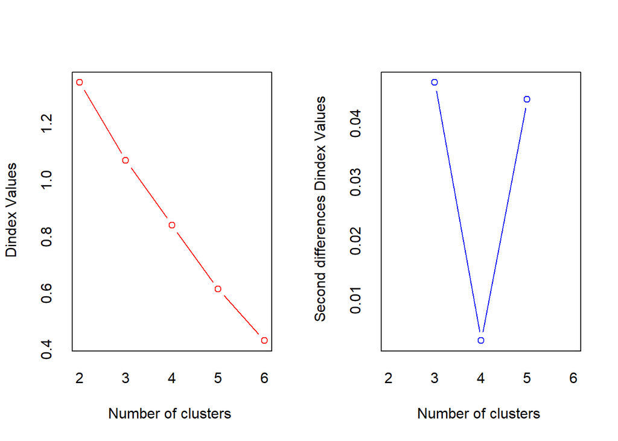

```
## *** : The D index is a graphical method of determining the number of clusters.
##                 In the plot of D index, we seek a significant knee (the significant peak in Dindex
##                 second differences plot) that corresponds to a significant increase of the value of
##                 the measure.
##
## * Among all indices:
## * 5 proposed 2 as the best number of clusters
## * 6 proposed 3 as the best number of clusters
## * 2 proposed 5 as the best number of clusters
## * 10 proposed 6 as the best number of clusters
##
##                    ***** Conclusion *****
##
## * According to the majority rule, the best number of clusters is  6
##
##
```

```r
matstd_sm <- scale(efa_data)

res.nbclust <- matstd_sm %>% scale() %>% NbClust(distance = "euclidean", min.nc = 2, max.nc = 6, method = "complete", index ="all")
```

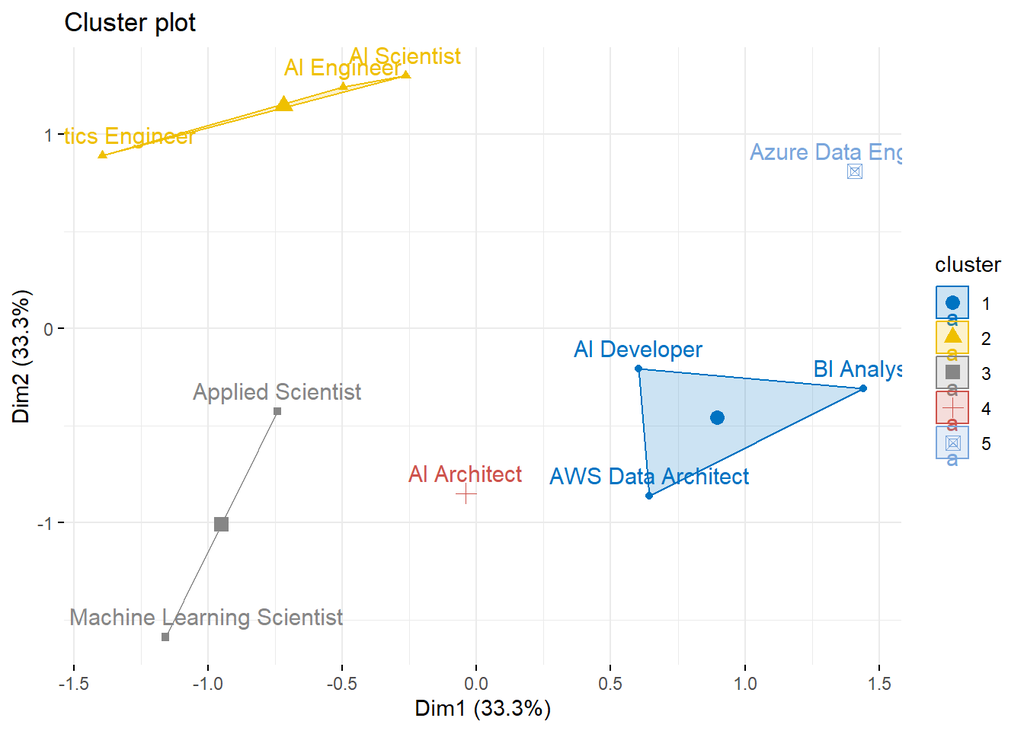

```r
km.res <- kmeans(matstd_sm, 5, nstart = 10)

fviz_cluster(km.res, data = matstd_sm,
             ellipse.type = "convex",
             palette = "jco",
             ggtheme = theme_minimal())
```

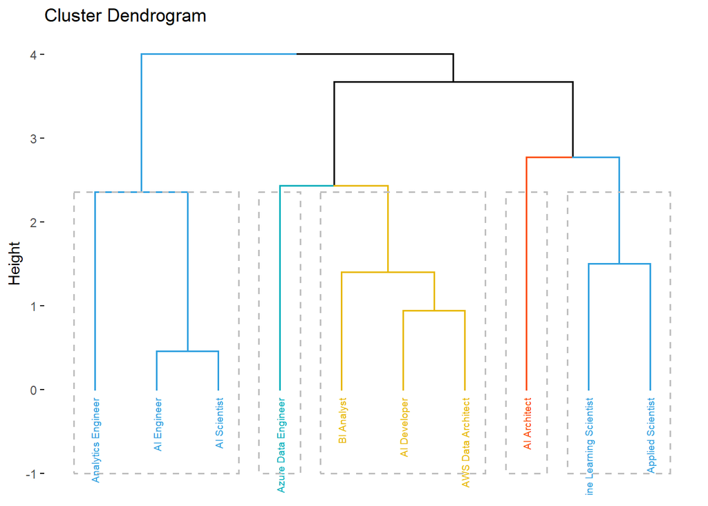

```r
dist.sc_dataset <- dist(matstd_sm, method="euclidean")

res.hc <- matstd_sm %>% scale() %>% dist(method = "euclidean") %>%
  hclust(method="ward.D2")

fviz_dend(res.hc, k = 5, # Cut in four groups
          cex = 0.5, # label size
          k_colors = c("#2E9FDF", "#00AFBB", "#E7B800", "#FC4E07"),
          color_labels_by_k = TRUE, # color labels by groups
          rect = TRUE # Add rectangle around groups
)
```

```r
Clustered <- ifelse(km.res$cluster > 1.5, "Low", "High")
Actual <- ifelse(sc_dataset$salaryLevel == 1, "High", "Low")
confusion_mat <- table(Clustered, Actual)
confusion_mat
```

```
##          Actual
## Clustered High Low
##      High    3   0
##      Low     3   4
```

```r
accuracy <- sum(diag(confusion_mat)) / sum(confusion_mat)
precision <- confusion_mat[2, 2] / sum(confusion_mat[, 2])
recall <- confusion_mat[2, 2] / sum(confusion_mat[2, ])
cat("Accuracy:", round(accuracy, 3), "\n")
```

```
## Accuracy: 0.7
```

```r
wdbc <- read.csv("/Users/Prateekg/Documents/MVA/Salary_multiple_regression.csv")
features <- c("Category", "Currency", "EmpResidence","ExpLevel", "EmpType", "WorkSetting", "location", "size", "level", "year", "salary", "USD","YearsExperience", "NoOfCompany", "SalaryLevel")
names(wdbc) <- c("Title", "Category", "Currency", "EmpResidence","ExpLevel", "EmpType", "WorkSetting", "location", "size", "level", "year", "salary", "USD", "YearsExperience", "NoOfCompany","SalaryLevel")
wdbc.data <- as.matrix(wdbc[,c(11:15)])
row.names(wdbc.data) <- wdbc$Title
wdbc_raw <- cbind(wdbc.data, as.numeric(as.factor(wdbc$SalaryLevel))-1)
colnames(wdbc_raw)[6] <- "EmpSalaryLevel"
smp_size_raw <- floor(0.70 * nrow(wdbc_raw))
train_ind_raw <- sample(nrow(wdbc_raw), size = smp_size_raw)
train_raw.df <- as.data.frame(wdbc_raw[train_ind_raw, ])
test_raw.df <- as.data.frame(wdbc_raw[-train_ind_raw, ])
```

Now divided the dataset into training and testing data for regression analysis.

We consider the training and testing data with a 70-30 split.

# MULTIPLE REGRESSION :

- Multiple regression is a statistical technique used to understand the relationship between one dependent variable and two or more independent variables.
- It aims to predict the value of the dependent variable based on the values of the independent variables.

```r
# MULTIPLE REGRESSION
#fit <- lm(TroubleInSleep~Instagram + Snapchat + Twitter, data=sc_dataset)
#x_sm <- cbind(train_ind_raw,train_raw.df[, -9])

fit <- lm( EmpSalaryLevel~ ., data = train_raw.df)

summary(fit)
```

```
##
## Call:
## lm(formula = EmpSalaryLevel ~ ., data = train_raw.df)
##
## Residuals:
##                 AWS Data Architect                         BI Analyst
##                         -1.236e-02                          6.353e-03
## Applied Machine Learning Scientist                       AI Developer
##                          6.621e-03                         -3.686e-17
##                 Analytics Engineer                        AI Engineer
##                         -3.349e-03                         -1.206e-02
##                       AI Scientist
##                          1.479e-02
##
## Coefficients:
##                   Estimate Std. Error t value Pr(>|t|)
## (Intercept)      1.899e+02  8.312e+00  22.843   0.0279 *
## year            -9.429e-02  4.136e-03 -22.795   0.0279 *
## salary          -2.536e-05  3.531e-06  -7.182   0.0881 .
## USD              4.938e-02  2.279e-02   2.166   0.2753
## YearsExperience  4.523e-02  2.151e-02   2.102   0.2826
## NoOfCompany      2.895e-05  3.463e-06   8.359   0.0758 .
## ---
## Signif. codes:  0 '***' 0.001 '**' 0.01 '*' 0.05 '.' 0.1 ' ' 1
##
## Residual standard error: 0.02475 on 1 degrees of freedom
## Multiple R-squared:  0.9996, Adjusted R-squared:  0.9979
## F-statistic: 559.7 on 5 and 1 DF,  p-value: 0.03208
```

```r
coefficients(fit)
```

```
##     (Intercept)            year          salary             USD YearsExperience
##    1.898694e+02   -9.429113e-02   -2.535841e-05    4.938080e-02    4.523085e-02
##     NoOfCompany
##    2.894627e-05
```

```r
residuals(fit)
```

```
##                 AWS Data Architect                         BI Analyst
##                      -1.236134e-02                       6.352889e-03
## Applied Machine Learning Scientist                       AI Developer
##                       6.620782e-03                      -3.686287e-17
##                 Analytics Engineer                        AI Engineer
##                      -3.348661e-03                      -1.205518e-02
##                       AI Scientist
##                       1.479152e-02
```

```r
probabilities_sm2 <- predict(fit, newdata = test_raw.df, type = "response")

predicted_sm2 <- ifelse(probabilities_sm2 > 0.5, "Yes", "No")
actual_sm <- ifelse(test_raw.df$EmpSalaryLevel == 1, "Yes", "No")
confusion_sm2 <- table(predicted_sm2, actual_sm)
confusion_sm2
```

```
##              actual_sm
## predicted_sm2 No Yes
##           No   0   1
##           Yes  1   1
```

```r
roc_sm <- roc(test_raw.df$EmpSalaryLevel, probabilities_sm2)
```

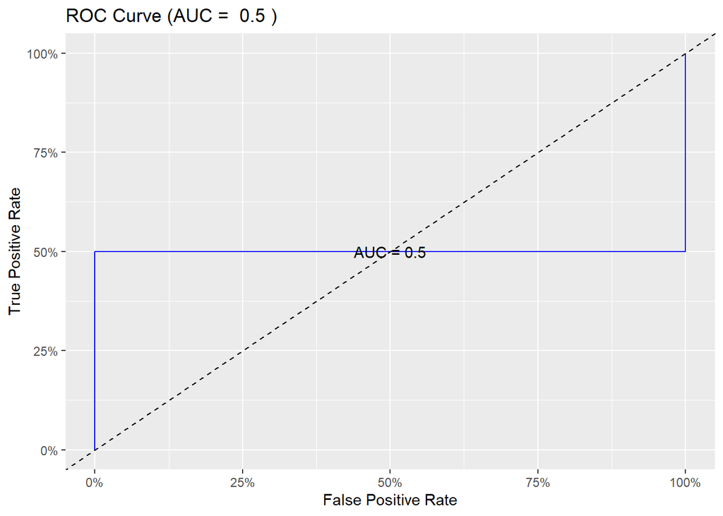

```r
auc_sm <- auc(roc_sm)

ggroc(roc_sm, color = "blue", legacy.axes = TRUE) +
  geom_abline(intercept = 0, slope = 1, linetype = "dashed") +
  scale_x_continuous(labels = scales::percent_format()) +
  scale_y_continuous(labels = scales::percent_format()) +
  labs(x = "False Positive Rate", y = "True Positive Rate",
       title = paste("ROC Curve (AUC = ", round(auc_sm, 2), ")")) +
  annotate("text", x = 0.5, y = 0.5, label = paste0("AUC = ", round(auc_sm, 2)))
```

```r
threshold<-0.5
predicted <- predict(fit, newdata = test_raw.df)

predicted_category <- ifelse(predicted > threshold, "High", "Low")

# Convert actual values to binary categories
actual_category <- ifelse(test_raw.df$EmpSalaryLevel == 1, "High", "Low")

# Create a confusion matrix
confusion_mat <- table(predicted_category, actual_category)

# Calculate accuracy
accuracy <- sum(diag(confusion_mat)) / sum(confusion_mat)
accuracy
```

```
## [1] 0.3333333
```

The regression summary shows that we have significant variables that affect the output variable.

# LOGISTIC REGRESSION :

- Logistic regression is a statistical method used for binary classification problems. It predicts the probability that a given observation belongs to one of two classes.
- It models the relationship between a binary dependent variable and one or more independent variables.

```r
# Logistic Regression

logistic_sm <- glm(EmpSalaryLevel ~ ., data = train_raw.df, family = 'binomial')
summary(logistic_sm)
```

```
##
## Call:
## glm(formula = EmpSalaryLevel ~ ., family = "binomial", data = train_raw.df)
##
## Coefficients:
##                   Estimate Std. Error z value Pr(>|z|)
## (Intercept)      9.314e+03  4.058e+07       0        1
## year            -4.638e+00  2.020e+04       0        1
## salary          -1.251e-03  1.811e+01       0        1
## USD              2.398e+00  1.376e+05       0        1
## YearsExperience  2.296e+00  1.154e+05       0        1
## NoOfCompany      1.428e-03  1.770e+01       0        1
##
## (Dispersion parameter for binomial family taken to be 1)
##
##     Null deviance: 9.5607e+00  on 6  degrees of freedom
## Residual deviance: 3.0337e-10  on 1  degrees of freedom
## AIC: 12
##
## Number of Fisher Scoring iterations: 23
```

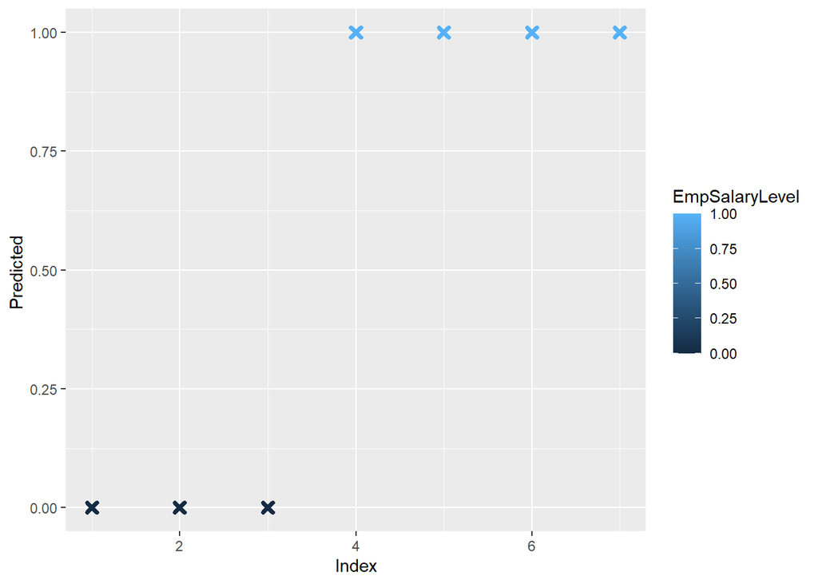

```r
predicted.data <- data.frame(probability.of.hd=logistic_sm$fitted.values,EmpSalaryLevel=train_raw.df$EmpSalaryLevel)
predicted.data <- predicted.data[order(predicted.data$probability.of.hd, decreasing=FALSE),]
predicted.data$rank <- 1:nrow(predicted.data)

ggplot(data=predicted.data, aes(x=rank, y=probability.of.hd)) +
  geom_point(aes(color=EmpSalaryLevel), alpha=1, shape=4, stroke=2) +
  xlab("Index") +
  ylab("Predicted ")
```

```r
probabilities_sm2 <- predict(logistic_sm, newdata = test_raw.df, type = "response")

predicted_sm2 <- ifelse(probabilities_sm2 > 0.5, "High", "Low")
actual_sm <- ifelse(test_raw.df$EmpSalaryLevel == 1, "High", "Low")
confusion_sm2 <- table(predicted_sm2, actual_sm)
confusion_sm2
```

```
##              actual_sm
## predicted_sm2 High Low
##          High    1   1
##          Low     1   0
```

```r
accuracy2 <- sum(diag(confusion_sm2)) / sum(confusion_sm2)
precision2 <- confusion_sm2[2, 2] / sum(confusion_sm2[, 2])
recall2 <- confusion_sm2[2, 2] / sum(confusion_sm2[2, ])
cat("Accuracy:", round(accuracy2, 3), "\n")
```

```
## Accuracy: 0.333
```

```r
cat("Precision:", round(precision2, 3), "\n")
```

```
## Precision: 0
```

```r
cat("Recall:", round(recall2, 3), "\n")
```

```
## Recall: 0
```

```r
probabilities <- predict(logistic_sm, newdata = test_raw.df, type = "response")

roc_sm <- roc(test_raw.df$EmpSalaryLevel, probabilities_sm2)
```

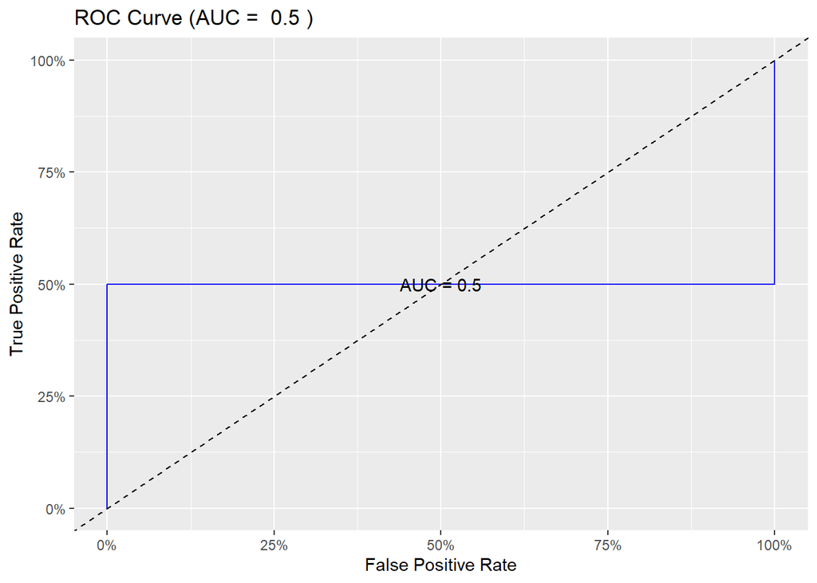

```r
auc_sm <- auc(roc_sm)

ggroc(roc_sm, color = "blue", legacy.axes = TRUE) +
  geom_abline(intercept = 0, slope = 1, linetype = "dashed") +
  scale_x_continuous(labels = scales::percent_format()) +
  scale_y_continuous(labels = scales::percent_format()) +
  labs(x = "False Positive Rate", y = "True Positive Rate",
       title = paste("ROC Curve (AUC = ", round(auc_sm, 2), ")")) +
  annotate("text", x = 0.5, y = 0.5, label = paste0("AUC = ", round(auc_sm, 2)))
```

These visualizations provide valuable insights into the logistic regression model’s performance by showcasing Accuracy and ROC Curve of the model.

# DISCRIMINANT :

- Discriminant analysis is a statistical method used for classification tasks that involve identifying which category or group a new observation belongs to based on one or more predictor variables (features).

```r
wdbc_raw.lda <- lda(formula = train_raw.df$EmpSalaryLevel ~ ., data = train_raw.df)
wdbc_raw.lda
```

```
## Call:
## lda(train_raw.df$EmpSalaryLevel ~ ., data = train_raw.df)
##
## Prior probabilities of groups:
##         0         1
## 0.4285714 0.5714286
##
## Group means:
##       year    salary   USD YearsExperience NoOfCompany
## 0 2019.333  73333.33 4.000        1.666667    73333.33
## 1 2016.500 247750.00 3.875        2.250000   250738.00
##
## Coefficients of linear discriminants:
##                          LD1
## year            -8.522005998
## salary          -0.002291886
## USD              4.463022598
## YearsExperience  4.087951432
## NoOfCompany      0.002616155
```

```r
summary(wdbc_raw.lda)
```

```
##         Length Class  Mode
## prior    2     -none- numeric
## counts   2     -none- numeric
## means   10     -none- numeric
## scaling  5     -none- numeric
## lev      2     -none- character
## svd      1     -none- numeric
## N        1     -none- numeric
## call     3     -none- call
## terms    3     terms  call
## xlevels  0     -none- list
```

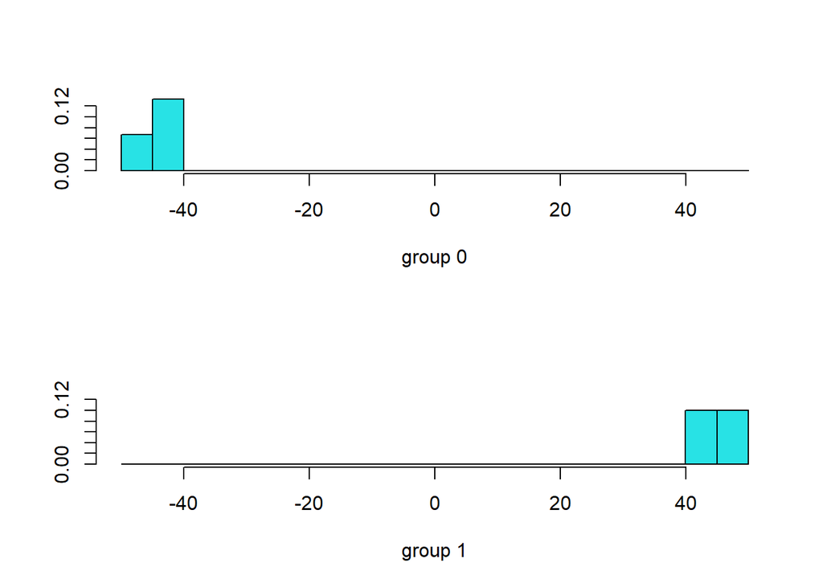

```r
plot(wdbc_raw.lda)
```

```r
predictions <- predict(wdbc_raw.lda, newdata = test_raw.df)
predicted_classes <- predictions$class
accuracy2 <- mean(predicted_classes == test_raw.df$EmpSalaryLevel)
accuracy2
```

```
## [1] 0.3333333
```

```r
wdbc_raw.lda.predict_train <- predict(wdbc_raw.lda, newdata = train_raw.df)
y<-wdbc_raw.lda.predict_train$class
wdbc_raw.lda.predict_train$x
```

```
##                                          LD1
## AWS Data Architect                  39.85138
## BI Analyst                          38.15999
## Applied Machine Learning Scientist  38.13578
## AI Developer                        38.73417
## Analytics Engineer                 -51.34290
## AI Engineer                        -50.55601
## AI Scientist                       -52.98241
```

```r
table(y,train_raw.df$EmpSalaryLevel)
```

```
##
## y   0 1
##   0 3 0
##   1 0 4
```

```r
wdbc_raw.lda.predict_test <- predict(wdbc_raw.lda, newdata = test_raw.df)
y<-wdbc_raw.lda.predict_test$class
wdbc_raw.lda.predict_test$x
```

```
##                           LD1
## AI Architect         54.16299
## Applied Scientist   -22.86052
## Azure Data Engineer  38.00834
```

```r
table(y,test_raw.df$EmpSalaryLevel)
```

```
##
## y   0 1
##   0 0 1
##   1 1 1
```

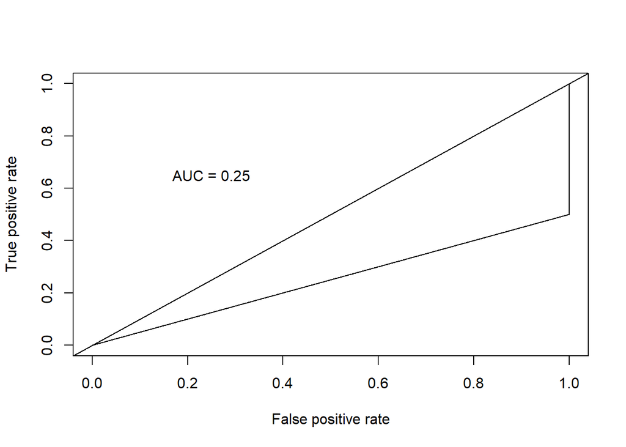

```r
wdbc_raw.lda.predict.posteriors <- as.data.frame(wdbc_raw.lda.predict_test$posterior)
pred <- prediction(wdbc_raw.lda.predict.posteriors[,2], test_raw.df$EmpSalaryLevel)
roc.perf = performance(pred, measure = "tpr", x.measure = "fpr")
auc.train <- performance(pred, measure = "auc")
auc.train <- auc.train@y.values
plot(roc.perf)
abline(a=0, b= 1)
text(x = .25, y = .65 ,paste("AUC = ", round(auc.train[[1]],3), sep = ""))
```

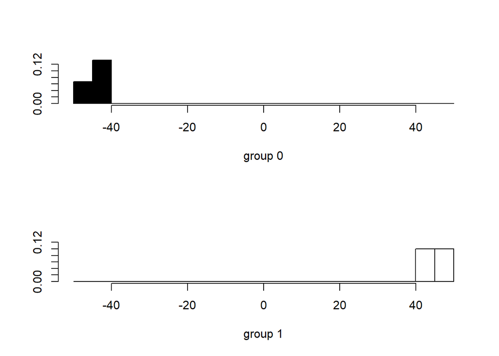

```r
plot(wdbc_raw.lda, col = as.integer(train_raw.df$EmpSalaryLevel))
```